# Analysis for the manuscript: Serial passage of the human probiotic *E. coli* Nissle in an insect host leads to changed bacterial phenotypes, Schröder & Korsa et al. 2020, submitted to iScience

Ana Korsa & Nicolas Schröder produced the following file

December, 2020

This file consists of data analyses done for the manuscript: “Serial passage of the human probiotic *E. coli* Nissle in an insect host leads to changed bacterial phenotypes”

# Persistence analysis

```r
library(ggplot2)
#loads raw data into dataframe
persistence_data <- read.table("Persistence_EcN.csv", sep = ";", header=TRUE)

#shows data
persistence_data
```

| Sample | Treatment | Day | Growth |
| --- | --- | --- | --- |
| 1 | L1 | 1 | 1 |
| 2 | L1 | 1 | 1 |
| 3 | L1 | 1 | 1 |
| 4 | L1 | 1 | 1 |
| 5 | L1 | 1 | 1 |
| 6 | L1 | 1 | 1 |
| 7 | L1 | 1 | 1 |
| 8 | L1 | 1 | 1 |
| 9 | L1 | 1 | 1 |
| 10 | L1 | 1 | 0 |

[output cut: 990 more lines]

```r
#saves treatment strain names to list
namelist <- c("L1", "L2", "L3", "L4","L5","L6","L7","L8","L9","L10","A")

#creates empty dataframe with treatment strains as columns
pers_rate_df <- data.frame("L1"=rep(NA,7), "L2"=rep(NA,7),"L3"=rep(NA,7),"L4"=rep(NA,7),"L5"=rep(NA,7),"L6"=rep(NA,7),"L7"=rep(NA,7),"L8"=rep(NA,7),"L9"=rep(NA,7),"L10"=rep(NA,7),"A"=rep(NA,7))

#sets days as rows
row.names(pers_rate_df) <- c("day1", "day2", "day3", "day4", "day5", "day6", "day7")

# sets for loop counter to 0
x <- 0

#calculates and saves persistence rates based on the raw data for each treatment and day
for (name in namelist){
  #print(name)

  x <- x + 1
  y <- 1

  for (day in 1:7){
    pers_rate <- (sum(persistence_data[,2]==name & persistence_data[,3]==day & persistence_data[,4]==1) / sum(persistence_data[,2]==name & persistence_data[,3]==day))
    #print(pers_rate)
    pers_rate_df[y,x] <- pers_rate
    y <- y + 1
  }}
print(pers_rate_df)
```

|  | L1 | L2 | L3 | L4 | L5 | L6 | L7 | L8 | L9 | L10 | A |
| --- | --- | --- | --- | --- | --- | --- | --- | --- | --- | --- | --- |
| day1 | 0.45 | 0.10 | 0.5789474 | 0.55 | 0.6000000 | 0.45000000 | 0.40 | 0.5500 | 0.5263158 | 0.40000000 | 0.75 |
| day2 | 0.25 | 0.35 | 0.4000000 | 0.40 | 0.2941176 | 0.25000000 | 0.10 | 0.3500 | 0.3500000 | 0.25000000 | 0.15 |
| day3 | 0.05 | 0.15 | 0.2000000 | 0.10 | 0.1500000 | 0.20000000 | 0.15 | 0.1000 | 0.3500000 | 0.20000000 | 0.15 |
| day4 | 0.15 | 0.15 | 0.6500000 | 0.15 | 0.1500000 | 0.20000000 | 0.15 | 0.0500 | 0.0500000 | 0.10000000 | 0.10 |
| day5 | 0.20 | 0.05 | 0.2000000 | 0.05 | 0.0500000 | 0.10000000 | 0.05 | 0.0000 | 0.0000000 | 0.05000000 | 0.10 |
| day6 | 0.15 | 0.30 | 0.1000000 | 0.05 | 0.1500000 | 0.20000000 | 0.05 | 0.0500 | 0.0500000 | 0.05000000 | 0.05 |
| day7 | 0.05 | 0.05 | 0.0000000 | 0.00 | 0.1000000 | 0.05882353 | 0.05 | 0.0625 | 0.0000000 | 0.05555556 | 0.10 |

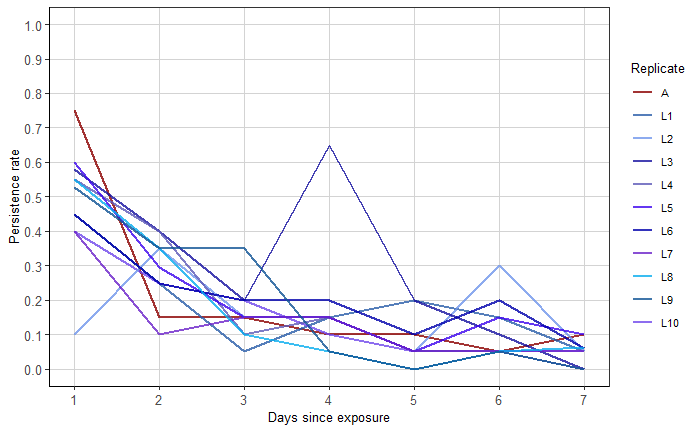

```r
#reorganizes the rows and columns of the persistence rates data frame to fit the required input format of ggplot2
pers_gg_input <- data.frame("sample"=1:77,
                            "persrate"=c(pers_rate_df$L1, pers_rate_df$L2, pers_rate_df$L3, pers_rate_df$L4, pers_rate_df$L5, pers_rate_df$L6, pers_rate_df$L7, pers_rate_df$L8,pers_rate_df$L9,pers_rate_df$L10, pers_rate_df$A),
                            "day"=rep(1:7,11),
                            "replicate"=c(rep("L1",7), rep("L2",7), rep("L3",7),rep("L4",7), rep("L5",7), rep("L6",7), rep("L7",7), rep("L8",7), rep("L9",7), rep("L10",7), rep("A",7)))


#plots the persitence rates
ggplot(pers_gg_input, aes(y = persrate, x = day, colour = replicate))+
  geom_line(size=1, alpha= 0.8)+
  theme_bw()+
  #ylim(0,1)+
  #theme(legend.position = "none")+
  xlab("Days since exposure")+
  ylab("Persistence rate")+
  theme(axis.text=element_text(size=10),axis.title=element_text(size=10,face="plain"))+
  scale_x_continuous(breaks = c(1,2,3,4,5,6,7))+
  scale_y_continuous(limits=c(0,1), breaks = scales::pretty_breaks(n = 10))+
  #ggtitle("EcN persistence")+
  theme(text=element_text(size=10))+
  scale_colour_manual("Replicate", breaks = c("A", "L1","L2"
                                              ,"L3","L4","L5","L6"
                                              ,"L7","L8","L9","L10"),values = c("#8b0000","#2a5ea9"
                                                                                ,"#7096eb", "#1711a0"
                                                                                ,"#5e5ab8" ,"#3d05ed"
                                                                                ,"#0000ab","#6c23c9"
                                                                                ,"#09aced","#105495"
                                                                                ,"#7048eb"))+
  theme(panel.grid.major = element_line(colour = "lightgrey"), panel.grid.minor = element_blank(), axis.line = element_line(colour = "black"))
```

```r
library(lme4)
gm1 <- glm(cbind(Growth, Day) ~ Treatment,data = persistence_data, family = binomial)
```

Testing assumptions

```r
#tests assumptions, doesn't test residual distribution, because of the binomial structure (1-colony presence ,0-no presence)
#cooks distance-for model without random effects:
max(cooks.distance(gm1))# should be <1.#
```

```
[1] 0.004348977
```

```r
max(abs(dffits(gm1)))# differences of <1 are fine.
```

```
[1] 0.1538038
```

Since the model fits, we will create a null model and run anova

```r
g0 <-glm(cbind(Growth, Day)~1,data=persistence_data,family=binomial)
anova(gm1,g0,test="Chisq")
```

```
Analysis of Deviance Table

Model 1: cbind(Growth, Day) ~ Treatment
Model 2: cbind(Growth, Day) ~ 1
  Resid. Df Resid. Dev  Df Deviance Pr(>Chi)
1      1511     1190.9
2      1521     1202.4 -10  -11.495   0.3203
```

There is no difference in persistence between the treatment lines

# Growth analysis

Raw data from the Tecan plate reader was adjusted and sorted for the analysis - File is melted_mead_d_sorted

```r
mean_d_melt_sorted <- read.table("melted_mean_d_sorted.csv", sep = ";", header=TRUE)

#shows data
mean_d_melt_sorted
```

| ID | time | strain | OD |
| --- | --- | --- | --- |
| 1 | 0.00 | A1 | 0.09167500 |
| 2 | 0.00 | A2 | 0.09300000 |
| 3 | 0.00 | A3 | 0.09360000 |
| 4 | 0.00 | A4 | 0.09310000 |
| 5 | 0.00 | A5 | 0.09175000 |
| 6 | 0.00 | A6 | 0.09037500 |
| 7 | 0.00 | F1 | 0.08957500 |
| 8 | 0.00 | F2 | 0.09027500 |
| 9 | 0.00 | F3 | 0.09015000 |
| 10 | 0.00 | F4 | 0.09007500 |

[output cut: 990 more lines]

```r
#adding a treatment column based on the stain name for grouping in plots and analyses

mean_d_melt_sorted$treatment <- NA                ## Adds a column called treatment

for (i in rownames(mean_d_melt_sorted)) {         ## This for loop checks to which treatment each sample belongs and adds the according name to the new "treatment" column

  ifelse(rownames(mean_d_melt_sorted)[as.numeric(i)] %in%  grep("blank", mean_d_melt_sorted$strain), mean_d_melt_sorted$treatment[as.numeric(i)] <- "blank",
         ifelse(rownames(mean_d_melt_sorted)[as.numeric(i)] %in%  grep("F", mean_d_melt_sorted$strain), mean_d_melt_sorted$treatment[as.numeric(i)] <- "F",
                ifelse(rownames(mean_d_melt_sorted)[as.numeric(i)] %in%  grep("L", mean_d_melt_sorted$strain), mean_d_melt_sorted$treatment[as.numeric(i)] <- "L", mean_d_melt_sorted$treatment[as.numeric(i)] <- "A")))


}



#plot
library(ggplot2)
library(cowplot)
```

```r
#Excludes blanks. Blanks were used as a negative control
means_no_blanks <- droplevels(subset(mean_d_melt_sorted,strain != "blank"))
```

Plotting the curves

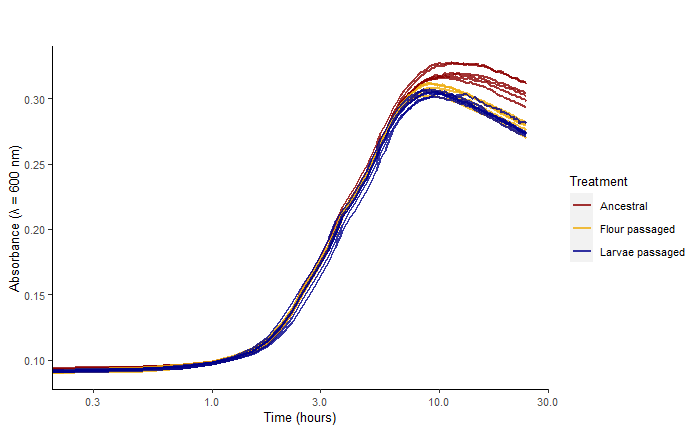

```r
c<-ggplot(means_no_blanks, aes(x=time, y=OD, group=strain)) +
  #geom_point(size=0.5, col="grey") +
  geom_line(size = 0.8, aes(x=time, y=OD, color= treatment), alpha=0.8)+
  theme(text=element_text(size=10))+
  ggtitle("")+
  theme(strip.background = element_blank())+
  labs(y=  "Absorbance (\u03bb = 600 nm)", x="Time (hours)", tag = "")+
  scale_color_manual("Treatment",labels = c("Ancestral", "Flour passaged", "Larvae passaged"),values=c("#8b0000", "#eead0e", "#00008b"))+
  theme(panel.grid.major = element_blank(), panel.grid.minor = element_blank(),
        panel.background = element_blank(), axis.line = element_line(colour = "black"))

c+  scale_x_log10()
```

Analyzing the growth For statistics we use the output file of the plate reader (but sorted, with all columns named as required). We will now run the growthcurver function on every biological replicate (strain), excluding blanks.

```r
mean_d <- read.csv("mean_d.csv", header=TRUE, sep=",")

#The ID column "X" needs to be removed otherwise growthcurver would analyze this as sample ODs
mean_d$X <- NULL


#install.packages("devtools")
#devtools::install_github("sprouffske/growthcurver")
library("growthcurver")


#mean_analysis is the variable with all the measurements. We use it to perform normal stats as we would with any dependent variable




mean_analysis <- SummarizeGrowthByPlate(mean_d, bg_correct = "blank") ## analyzes mean growth curves

write.csv(mean_analysis,"mean_analysis.csv")                          ## saves analysis as csv file


#show mean_analysis
mean_analysis
```

| sample | k | n0 | r | t_mid | t_gen | auc_l | auc_e | sigma | note |
| --- | --- | --- | --- | --- | --- | --- | --- | --- | --- |
| A1 | 0.2188955 | 0.007169738 | 0.9344342 | 3.622965 | 0.7417828 | 4.452640 | 4.447341 | 0.007182886 |  |
| A2 | 0.2222295 | 0.007919808 | 0.9004905 | 3.662510 | 0.7697440 | 4.510636 | 4.505301 | 0.006020827 |  |
| A3 | 0.2244417 | 0.008448010 | 0.8752640 | 3.703247 | 0.7919293 | 4.545600 | 4.539416 | 0.005473696 |  |
| A4 | 0.2260955 | 0.008994129 | 0.8550100 | 3.723690 | 0.8106890 | 4.573648 | 4.566529 | 0.005453853 |  |
| A5 | 0.2336443 | 0.009533847 | 0.8335177 | 3.787911 | 0.8315927 | 4.710761 | 4.701604 | 0.005743667 |  |
| A6 | 0.2338243 | 0.009303582 | 0.8607105 | 3.698768 | 0.8053198 | 4.735891 | 4.726957 | 0.005935061 |  |
| F1 | 0.2001732 | 0.005343958 | 1.0748856 | 3.345618 | 0.6448567 | 4.129414 | 4.126529 | 0.009636037 |  |
| F2 | 0.2049423 | 0.006078940 | 1.0298618 | 3.386656 | 0.6730487 | 4.218554 | 4.215835 | 0.009277227 |  |
| F3 | 0.2084987 | 0.005940224 | 1.0231217 | 3.449523 | 0.6774826 | 4.278857 | 4.275666 | 0.009721863 |  |
| F4 | 0.2028190 | 0.005474831 | 1.0392140 | 3.449518 | 0.6669918 | 4.162687 | 4.159547 | 0.009534395 |  |

[output cut: 9 more lines]

```r
# Diagnostics

library(dplyr)
library(magrittr)
```

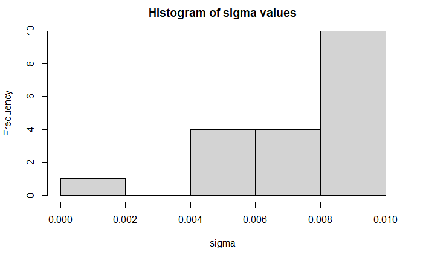

```r
# Plots a histogram of the sigma values in order to check for outliers. High sigma values are not good
hist(mean_analysis$sigma, main = "Histogram of sigma values", xlab = "sigma")
```

```r
# Show the top 5 samples with the largest sigma value
# (with the worst model fit to the growth curve data)
mean_analysis %>% top_n(5, sigma) %>% arrange(desc(sigma))
```

| sample | k | n0 | r | t_mid | t_gen | auc_l | auc_e | sigma | note |
| --- | --- | --- | --- | --- | --- | --- | --- | --- | --- |
| L5 | 0.2041020 | 0.006096496 | 1.020134 | 3.411885 | 0.6794666 | 4.196008 | 4.193535 | 0.009848803 |  |
| F3 | 0.2084987 | 0.005940224 | 1.023122 | 3.449523 | 0.6774826 | 4.278857 | 4.275666 | 0.009721863 |  |
| F1 | 0.2001732 | 0.005343958 | 1.074886 | 3.345618 | 0.6448567 | 4.129414 | 4.126529 | 0.009636037 |  |
| L2 | 0.2035020 | 0.006227786 | 1.050247 | 3.290249 | 0.6599850 | 4.208454 | 4.205907 | 0.009595984 |  |
| F5 | 0.2091111 | 0.006725981 | 0.996035 | 3.417746 | 0.6959065 | 4.297115 | 4.294579 | 0.009548450 |  |

```r
# Checks if growthcurver returned any notes (errors) for any growth curve
# from SummarizeGrowthByPlate
mean_analysis %>% filter(note != "")
```

| sample | k | n0 | r | t_mid | t_gen | auc_l | auc_e | sigma | note |
| --- | --- | --- | --- | --- | --- | --- | --- | --- | --- |

```r
#Stats
# loads the data
mean_analysis_sorted <- read.csv("mean_analysis_sorted.csv", header=TRUE, sep=",")
```

From the values we got, we will analyze growth rate (r) and carrying capacity (k) First normality test of growth rate and carrying capacity

```r
library("lme4")
library("lmerTest")
library("car")
library("influence.ME")

#Normality test

shapiro.test(mean_analysis_sorted$r)  # r is not normally distributed
```

```
    Shapiro-Wilk normality test

data:  mean_analysis_sorted$r
W = 0.88755, p-value = 0.03504
```

```r
shapiro.test(mean_analysis_sorted$k)  #k is not normally distributed
```

```
    Shapiro-Wilk normality test

data:  mean_analysis_sorted$k
W = 0.84691, p-value = 0.007573
```

```r
#p-value < 0.05 implying that the distribution of the data is significantly different from normal distribution
```

## Growth rate analysis

Analysis was done with Kruskal test followed with pairwise Wilcox test, Benjamini-Hochberg adjusted p-values.

```r
kruskal.test(r ~ treatment, data = mean_analysis_sorted)
```

```
    Kruskal-Wallis rank sum test

data:  r by treatment
Kruskal-Wallis chi-squared = 10.889, df = 2, p-value = 0.00432
```

```r
pairwise.wilcox.test(mean_analysis_sorted$r, mean_analysis_sorted$treatment,
                     p.adjust.method = "BH")
```

```
    Pairwise comparisons using Wilcoxon rank sum exact test

data:  mean_analysis_sorted$r and mean_analysis_sorted$treatment

  A      F
F 0.0065 -
L 0.0065 0.6991

P value adjustment method: BH
```

## Carrying capacity analysis

Analysis was done with Kruskal test followed with pairwise Wilcox test, Benjamini-Hochberg adjusted p-values.

```r
kruskal.test(k ~ treatment, data = mean_analysis_sorted)
```

```
    Kruskal-Wallis rank sum test

data:  k by treatment
Kruskal-Wallis chi-squared = 12.316, df = 2, p-value = 0.002117
```

```r
pairwise.wilcox.test(mean_analysis_sorted$k, mean_analysis_sorted$treatment,
                     p.adjust.method = "BH")
```

```
    Pairwise comparisons using Wilcoxon rank sum exact test

data:  mean_analysis_sorted$k and mean_analysis_sorted$treatment

  A      F
F 0.0032 -
L 0.0032 0.1797

P value adjustment method: BH
```

## Plotting the growth rate

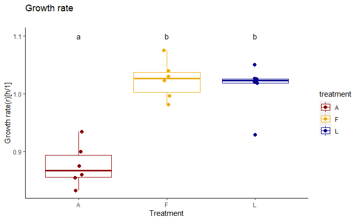

```r
p<-ggplot(mean_analysis_sorted, aes(x=treatment, y=r, col=treatment))+
  geom_boxplot(outlier.colour=NA, position=position_dodge(width=1),notch=FALSE, size=0.7)+
  geom_jitter(position=position_jitter(w=0.04,h=0), alpha=1, size=2)+
  theme(text = element_text(size=11))+
  labs(x="Treatment", y="Growth rate(r)[h/1]")+
  ggtitle("Growth rate", subtitle = "")+
  scale_color_manual(values=c("darkred", "darkgoldenrod2","darkblue"))+ annotate("text", label=c("a", "b", "b"), x=1:3,y=1.1)


rate<-p + theme(panel.grid.major = element_blank(), panel.grid.minor = element_blank(),
                panel.background = element_blank(), axis.line = element_line(colour = "black"))

rate
```

## Carrying capacity

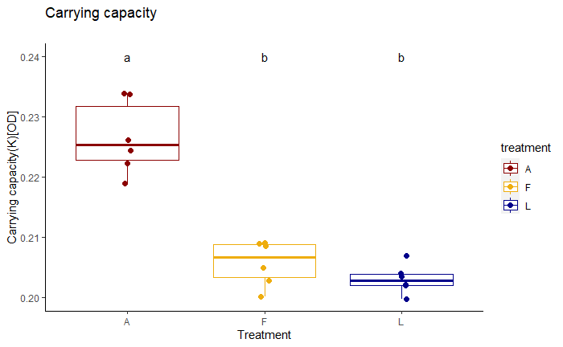

```r
p<-ggplot(mean_analysis_sorted, aes(x=treatment, y=k, col=treatment))+
  geom_boxplot(outlier.colour=NA, position=position_dodge(width=1),notch=FALSE, size=0.7)+
  geom_jitter(position=position_jitter(w=0.04,h=0), alpha=1, size=2)+
  theme(text = element_text(size=11))+
  labs(x="Treatment", y="Carrying capacity(K)[OD]")+
  ggtitle("Carrying capacity", subtitle = "")+
  scale_color_manual(values=c("darkred", "darkgoldenrod2","darkblue"))+annotate("text", label=c("a", "b", "b"), x=1:3,y=0.24)

K<-p + theme(panel.grid.major = element_blank(), panel.grid.minor = element_blank(),
             panel.background = element_blank(), axis.line = element_line(colour = "black"))

K
```

PCA plot based on carrying capacity, growth rate and area under the curve (auc_e)

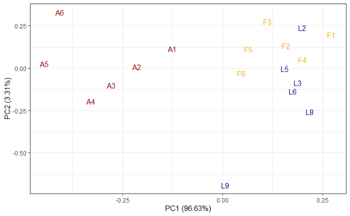

```r
pca_d <- mean_analysis_sorted

rownames(pca_d) <- pca_d$strain

pca.res <- prcomp(pca_d %>% dplyr::select(t_gen, auc_e,k,r), center=TRUE, scale=TRUE)

pca_df <- as_tibble(list(PC1=pca.res$x[,1],
                             PC2=pca.res$x[,2],
                             samples = rownames(pca_d)))


library(grid)
library(gridExtra)
library(ggfortify)
library(ggrepel)
library(ggpubr)



pca<-autoplot(pca.res, data = pca_d, colour = 'treatment',label=TRUE, label.size=4,shape=FALSE,label.show.legend = FALSE)+scale_colour_manual(values=c("darkred","darkgoldenrod2","darkblue"))+
  scale_fill_manual(values=c("darkred","darkgoldenrod2","darkblue"))+
  scale_shape_manual(values=c(25,22,23))+
  theme_bw()

pca
```

# Motility analysis

Diameter on swarming agar was measured at 2 time points: 6h and 9h after inoculation. Below you can find the analysis and plots for those 2 time points. They were analyzed separately.

```r
data2<- read.table("Readouts_time1.txt", sep = "\t", header = TRUE)
data3<- read.table("Readouts_time2.txt", sep = "\t", header = TRUE)
```

## First time point

```r
#shows data
data2
```

| Isolate | Colony | Diameter | Replicate | Treatment |
| --- | --- | --- | --- | --- |
| 1 | A1-1 | 0.90 | A1 | Ancestral |
| 2 | A1-2 | 0.80 | A1 | Ancestral |
| 3 | A1-3 | 0.63 | A1 | Ancestral |
| 4 | A2-1 | 0.60 | A2 | Ancestral |
| 5 | A2-2 | 0.60 | A2 | Ancestral |
| 6 | A2-3 | 0.57 | A2 | Ancestral |
| 7 | A3-1 | 0.73 | A3 | Ancestral |
| 8 | A3-2 | 0.60 | A3 | Ancestral |
| 9 | A3-3 | 0.63 | A3 | Ancestral |
| 10 | A4-1 | 0.80 | A4 | Ancestral |

[output cut: 44 more lines]

Plotting

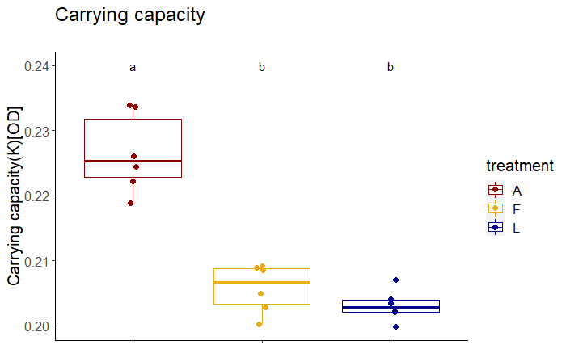

```r
Np<-ggplot(data2, aes(x=Treatment, y=Diameter, col=Treatment))+
  geom_boxplot(outlier.colour=NA, position=position_dodge(width=1),notch=FALSE, size=0.7)+
  geom_jitter(position=position_jitter(w=0.04,h=0), alpha=1, size=2)+
  theme(text = element_text(size=15))+
  labs(x="Treatment", y="Diameter")+
  ggtitle("Flagella 6h", subtitle = "")+
  scale_color_manual(values=c("darkred", "darkgoldenrod2","darkblue"))+annotate("text", label=c("a", "b", "b"), x=1:3,y=1.3)


###without a name of axis, so I dont repeat the information
p1<-p+theme(panel.grid.major = element_blank(), panel.grid.minor = element_blank(),
            panel.background = element_blank(), axis.line = element_line(colour = "black"),axis.text.x=element_blank(),axis.title.x=element_blank())+theme(text = element_text(size = 15))


p1
```

Analysis

First, with Shapiro test we check for the data distribution

```r
shapiro.test(data2$Diameter) ##normal , I can use parametric test - anova
```

```
    Shapiro-Wilk normality test

data:  data2$Diameter
W = 0.97293, p-value = 0.2588
```

We are using one-way anova

```r
##using one way anova
a1 <- aov(data2$Diameter~data2$Treatment)
```

Before, we have to check the assumptions for anova

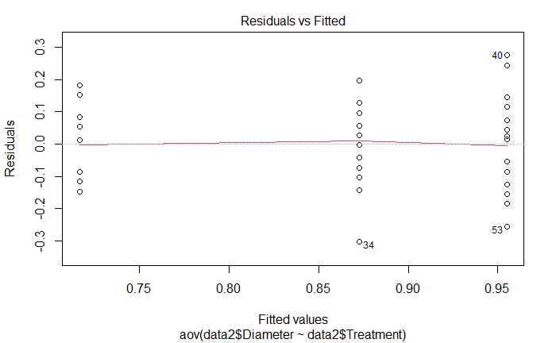

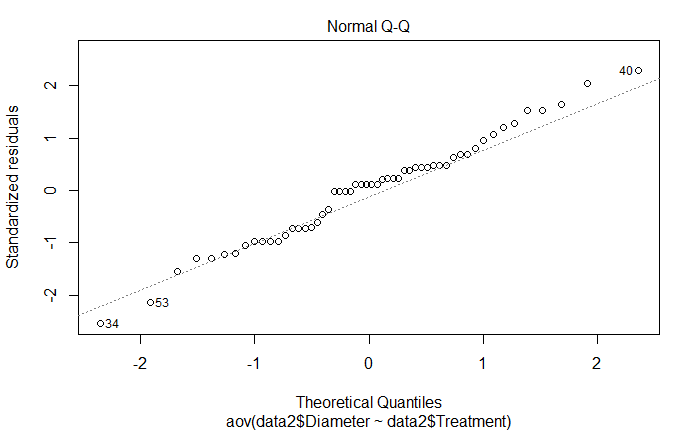

```
hat values (leverages) are all = 0.05555556
 and there are no factor predictors; no plot no. 5
```

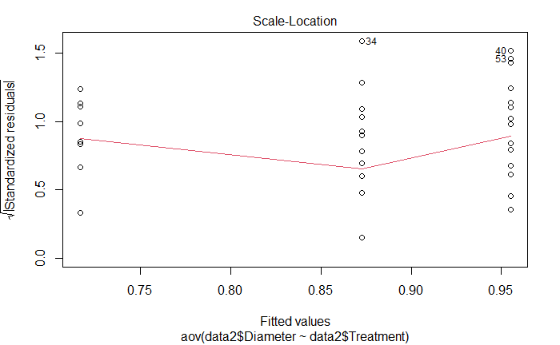

```r
plot(a1)
```

```r
library(car)
leveneTest(Diameter ~ Treatment, data = data2)
```

```
group coerced to factor.
```

```
Levene's Test for Homogeneity of Variance (center = median)
      Df F value Pr(>F)
group  2  0.9155 0.4068
      51
```

There is no evidence for violation of assumption (p>0.05)

1 way anova test:

```r
anova(a1)
```

```
Analysis of Variance Table

Response: data2$Diameter
                Df  Sum Sq  Mean Sq F value    Pr(>F)
data2$Treatment  2 0.52760 0.263802  17.418 1.716e-06 ***
Residuals       51 0.77241 0.015145
---
Signif. codes:  0 ‘***’ 0.001 ‘**’ 0.01 ‘*’ 0.05 ‘.’ 0.1 ‘ ’ 1
```

Tukey Honest Significant Differences test

```r
Tu <-TukeyHSD(a1)###shows a difference in the treatment
Tu
```

```
  Tukey multiple comparisons of means
    95% family-wise confidence level

Fit: aov(formula = data2$Diameter ~ data2$Treatment)

$`data2$Treatment`
                                     diff         lwr       upr     p adj
Flour_passaged-Ancestral       0.15611111  0.05708460 0.2551376 0.0010912
Larvae_passaged-Ancestral      0.23833333  0.13930682 0.3373598 0.0000012
Larvae_passaged-Flour_passaged 0.08222222 -0.01680429 0.1812487 0.1214548
```

## Second time point

```r
#shows data
data3
```

| Isolate | Colony | Diameter | Replicate | Treatment |
| --- | --- | --- | --- | --- |
| 1 | A1-1 | 2.00 | A1 | Ancestral |
| 2 | A1-2 | 1.87 | A1 | Ancestral |
| 3 | A1-3 | 1.67 | A1 | Ancestral |
| 4 | A2-1 | 1.57 | A2 | Ancestral |
| 5 | A2-2 | 1.53 | A2 | Ancestral |
| 6 | A2-3 | 1.50 | A2 | Ancestral |
| 7 | A3-1 | 1.70 | A3 | Ancestral |
| 8 | A3-2 | 1.57 | A3 | Ancestral |
| 9 | A3-3 | 1.65 | A3 | Ancestral |
| 10 | A4-1 | 1.80 | A4 | Ancestral |

[output cut: 44 more lines]

Plotting the data

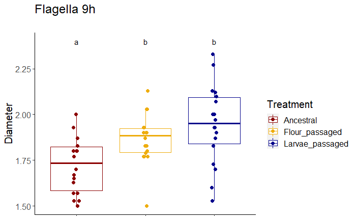

```r
p<-ggplot(data3, aes(x=Treatment, y=Diameter, col=Treatment))+
  geom_boxplot(outlier.colour=NA, position=position_dodge(width=1),notch=FALSE, size=0.7)+
  geom_jitter(position=position_jitter(w=0.04,h=0), alpha=1, size=2)+
  theme(text = element_text(size=15))+
  labs(x=NULL, y="Diameter")+
  ggtitle("Flagella 9h", subtitle = "")+
  scale_color_manual(values=c("darkred", "darkgoldenrod2","darkblue"))+annotate("text", label=c("a", "b", "b"), x=1:3,y=2.4)+theme(text = element_text(size = 15))



###without a name of axis, so i dont repeat the information
p2<-p+theme(panel.grid.major = element_blank(), panel.grid.minor = element_blank(),
            panel.background = element_blank(), axis.line = element_line(colour = "black"),axis.text.x=element_blank(),axis.title.x=element_blank()+theme(legend.position = "none"))
p2
```

Analysis

```r
shapiro.test(data3$Diameter) ##normal , I can use parametric test - anova
```

```
    Shapiro-Wilk normality test

data:  data3$Diameter
W = 0.97723, p-value = 0.3909
```

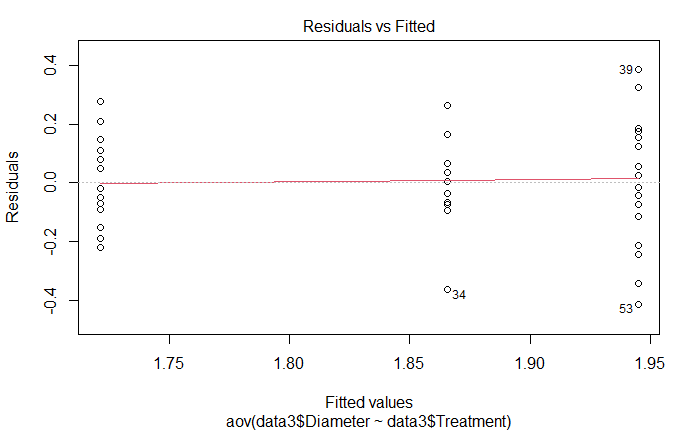

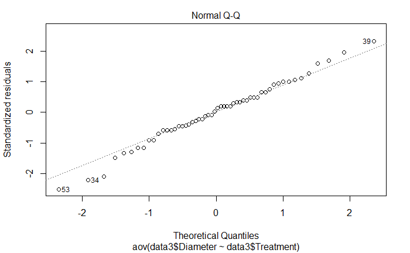

```
hat values (leverages) are all = 0.05555556
 and there are no factor predictors; no plot no. 5
```

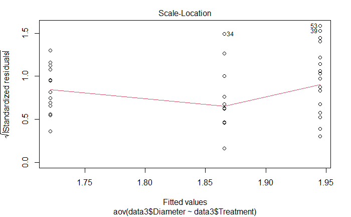

```r
##using one way anova
a1 <- aov(data3$Diameter~data3$Treatment)

#checking the assumptions
plot(a1)
```

```r
leveneTest(Diameter ~ Treatment, data = data2)
```

```
group coerced to factor.
```

```
Levene's Test for Homogeneity of Variance (center = median)
      Df F value Pr(>F)
group  2  0.9155 0.4068
      51
```

```r
anova(a1)
```

```
Analysis of Variance Table

Response: data3$Diameter
                Df  Sum Sq  Mean Sq F value    Pr(>F)
data3$Treatment  2 0.46381 0.231906  8.0629 0.0009065 ***
Residuals       51 1.46687 0.028762
---
Signif. codes:  0 ‘***’ 0.001 ‘**’ 0.01 ‘*’ 0.05 ‘.’ 0.1 ‘ ’ 1
```

```r
##posthoc

Tu<-TukeyHSD(a1)###shows a difference in the treatment
Tu
```

```
  Tukey multiple comparisons of means
    95% family-wise confidence level

Fit: aov(formula = data3$Diameter ~ data3$Treatment)

$`data3$Treatment`
                                     diff          lwr       upr     p adj
Flour_passaged-Ancestral       0.14444444  0.007978785 0.2809101 0.0357777
Larvae_passaged-Ancestral      0.22388889  0.087423229 0.3603545 0.0006716
Larvae_passaged-Flour_passaged 0.07944444 -0.057021215 0.2159101 0.3457680
```

# Survival analysis

We first analyzed *T. castaneum* larvae that were fed with EcN and then put on PBS - to see if there is any effect of *E.coli* pretreatment on the survival.

```r
library (survival)
library(ggplot2)
library(ggfortify)
library(survminer)
library(coxme)
library(RColorBrewer)
library(car)
library(lme4)
data1<- read.table("Survival.txt", header =TRUE, sep="\t" )
##only PBS plates
dataP<-subset(data1,Treatment=="P")

#shows data
dataP
```

|  | Sample | Plate | Pretreatment | Treatment | Day.of.Death | Survival | Regime |
| --- | --- | --- | --- | --- | --- | --- | --- |
| 1 | 1 | 1 | K | P | 2 | 1 | KP |
| 2 | 2 | 1 | K | P | 3 | 1 | KP |
| 3 | 3 | 1 | K | P | 9 | 1 | KP |
| 4 | 4 | 1 | K | P | 14 | 0 | KP |
| 5 | 5 | 1 | K | P | 14 | 0 | KP |
| 6 | 6 | 1 | K | P | 14 | 0 | KP |
| 7 | 7 | 1 | K | P | 14 | 0 | KP |
| 8 | 8 | 1 | K | P | 14 | 0 | KP |
| 9 | 9 | 1 | K | P | 14 | 0 | KP |
| 10 | 10 | 1 | K | P | 14 | 0 | KP |

[output cut: 990 more lines]

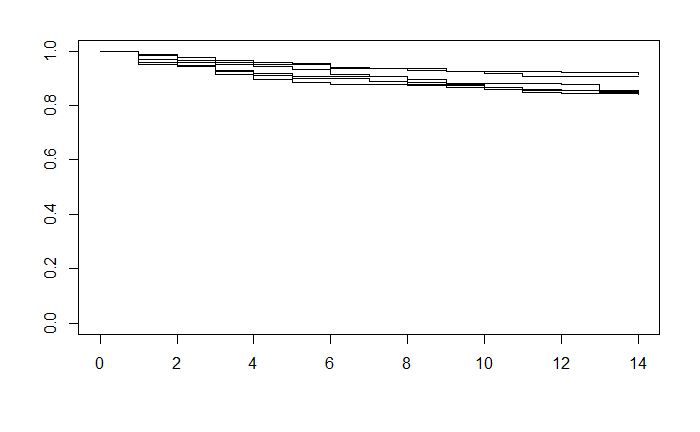

```r
plotP<-survfit(Surv(dataP$Day.of.Death, dataP$Survival)~dataP$Pretreatment)
plot(plotP)
```

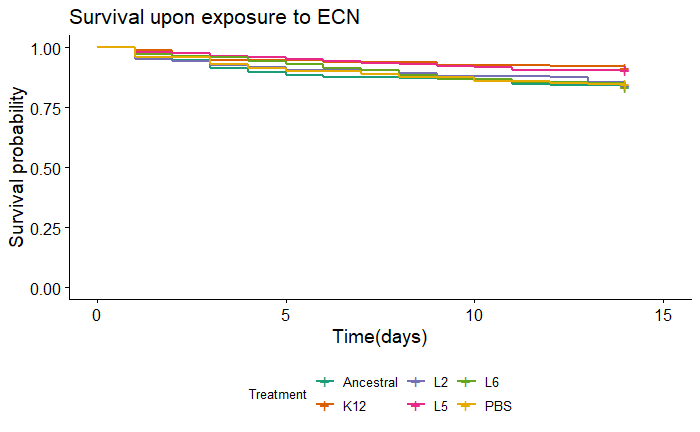

```r
surv_CP<-ggsurvplot(plotP,data=dataP, fun=NULL, legend = "bottom",main=NULL,xlab="Time(days)",palette="Dark2", legend.title= "Treatment",legend.labs = c("Ancestral","K12","L2","L5","L6","PBS"))
surv_CP +ggtitle("Survival upon exposure to ECN")
```

We will use coxph because we only have one random effect(Plate). By using coxph we can check for assumptions of the model.

```r
res <- coxph(Surv(Day.of.Death, Survival)~Pretreatment+frailty(Plate), data=dataP, method="efron")


#(1) Schoenfeld residuals

cox.zph(res)
```

```
             chisq  df    p
Pretreatment  2.95 5.0 0.71
GLOBAL        2.95 9.4 0.97
```

```r
#proportional hazards are met

#(2) Influential observations (akin to dfbetas in linear regression)

dfbeta=residuals(res, type="dfbeta")
max(abs(dfbeta))
```

```
[1] 0.06646418
```

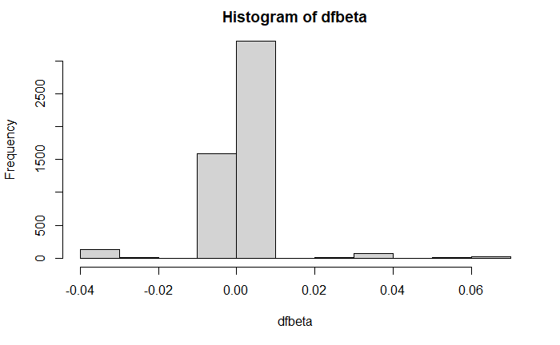

```r
hist(dfbeta)
```

```r
#The value is <2 so it is ok to proceed
```

Null model and anova

```r
res0 <-coxph(Surv(Day.of.Death,Survival)~1 + frailty(Plate),data=dataP)

anova(res,res0,test="Chisq")
```

```
Analysis of Deviance Table
 Cox model: response is  Surv(Day.of.Death, Survival)
 Model 1: ~ Pretreatment + frailty(Plate)
 Model 2: ~ 1 + frailty(Plate)
   loglik  Chisq    Df P(>|Chi|)
1 -929.98
2 -934.86 9.7571 5.026    0.0836 .
---
Signif. codes:  0 ‘***’ 0.001 ‘**’ 0.01 ‘*’ 0.05 ‘.’ 0.1 ‘ ’ 1
```

The model is not significant

Next, we will check if there is a difference in survival upon Btt treatment

```r
dataB <- subset(data1,Treatment=="B")

#shows data
dataB
```

|  | Sample | Plate | Pretreatment | Treatment | Day.of.Death | Survival | Regime |
| --- | --- | --- | --- | --- | --- | --- | --- |
| 78 | 78 | 2 | K | B | 1 | 1 | KB |
| 79 | 79 | 2 | K | B | 1 | 1 | KB |
| 80 | 80 | 2 | K | B | 1 | 1 | KB |
| 81 | 81 | 2 | K | B | 1 | 1 | KB |
| 82 | 82 | 2 | K | B | 1 | 1 | KB |
| 83 | 83 | 2 | K | B | 1 | 1 | KB |
| 84 | 84 | 2 | K | B | 1 | 1 | KB |
| 85 | 85 | 2 | K | B | 1 | 1 | KB |
| 86 | 86 | 2 | K | B | 1 | 1 | KB |
| 87 | 87 | 2 | K | B | 3 | 1 | KB |

[output cut: 990 more lines]

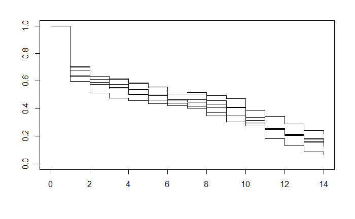

```r
plotB <- survfit(Surv(dataB$Day.of.Death, dataB$Survival)~dataB$Pretreatment)
plot(plotB)
```

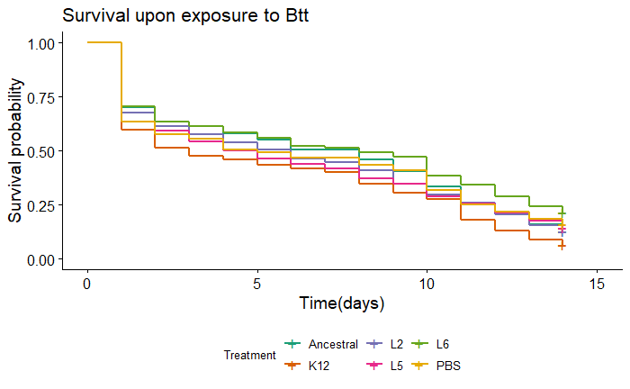

```r
surv_CP<-ggsurvplot(plotB,data=dataB, fun=NULL, legend = "bottom",main=NULL,xlab="Time(days)",palette="Dark2", legend.title= "Treatment",legend.labs = c("Ancestral","K12","L2","L5","L6","PBS"))
surv_CP +ggtitle("Survival upon exposure to Btt")
```

We will use coxph because we only have one random effect(Plate). By using coxph we can check for assumptions of the model.

```r
res=coxph(Surv(Day.of.Death, Survival)~Pretreatment+frailty(Plate), data=dataB, method="efron")


#(1) Schoenfeld residuals

cox.zph(res)
```

```
             chisq df    p
Pretreatment  5.89  5 0.32
GLOBAL        5.89  5 0.32
```

```r
#proportional hazards are met

#(2) Influential observations (akin to dfbetas in linear regression)

dfbeta=residuals(res, type="dfbeta")
max(abs(dfbeta))
```

```
[1] 0.01502792
```

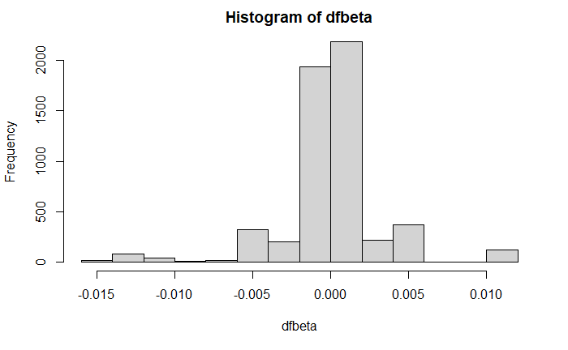

```r
hist(dfbeta)
```

```r
#The value is <2 so it is ok to proceed
```

Building a null model and testing with anova

```r
res0 <-coxph(Surv(Day.of.Death, Survival)~1 + frailty(Plate),data=dataB)

anova(res,res0,test="Chisq")
```

```
Analysis of Deviance Table
 Cox model: response is  Surv(Day.of.Death, Survival)
 Model 1: ~ Pretreatment + frailty(Plate)
 Model 2: ~ 1 + frailty(Plate)
   loglik  Chisq Df P(>|Chi|)
1 -5962.2
2 -5970.6 16.912  5  0.004671 **
---
Signif. codes:  0 ‘***’ 0.001 ‘**’ 0.01 ‘*’ 0.05 ‘.’ 0.1 ‘ ’ 1
```

```r
library(multcomp)
tuk=summary(glht(res, linfct=mcp(Pretreatment="Tukey"), group=TRUE), test=adjusted("BH"))
tuk.cld <- cld(tuk)
summary(tuk)  #L6-K
```

```
     Simultaneous Tests for General Linear Hypotheses

Multiple Comparisons of Means: Tukey Contrasts


Fit: coxph(formula = Surv(Day.of.Death, Survival) ~ Pretreatment +
    frailty(Plate), data = dataB, method = "efron")

Linear Hypotheses:
              Estimate Std. Error z value Pr(>|z|)
K - A == 0    0.264022   0.109868   2.403    0.155
L2 - A == 0   0.049004   0.110951   0.442    0.998
L3 - A == 0   0.052047   0.112593   0.462    0.997
L6 - A == 0  -0.196083   0.114038  -1.719    0.518
P - A == 0    0.002601   0.112968   0.023    1.000
L2 - K == 0  -0.215018   0.110032  -1.954    0.369
L3 - K == 0  -0.211976   0.111715  -1.897    0.403
L6 - K == 0  -0.460106   0.113305  -4.061   <0.001 ***
P - K == 0   -0.261421   0.112119  -2.332    0.181
L3 - L2 == 0  0.003042   0.112743   0.027    1.000
L6 - L2 == 0 -0.245088   0.114213  -2.146    0.264
P - L2 == 0  -0.046403   0.113139  -0.410    0.999
L6 - L3 == 0 -0.248130   0.115760  -2.143    0.265
P - L3 == 0  -0.049446   0.114724  -0.431    0.998
P - L6 == 0   0.198684   0.116110   1.711    0.524
---
Signif. codes:  0 ‘***’ 0.001 ‘**’ 0.01 ‘*’ 0.05 ‘.’ 0.1 ‘ ’ 1
(Adjusted p values reported -- single-step method)
```

There is a significant difference in survival between the treatments L6 and K12

# qPCR analyis

Already analyzed deltaCp values were imported. Data were subset according to the genes we wanted to analyze We need the following package for plotting the data.

```r
library(ggplot2)
library(car)
```

```r
library(readr)
qPCR_data_amp <- read.csv("qPCR_data_amp.csv", h=TRUE, sep= ";")

#show data
qPCR_data_amp
```

| Sample | Target | X.Cp |
| --- | --- | --- |
| ECN | Att1 | 11.272044 |
| ECN | Att1 | 9.795561 |
| ECN | Att1 | 10.452753 |
| ECN | Att1 | 10.333295 |
| ECN | Att1 | 10.185753 |
| ECN | Att1 | 11.335633 |
| K12 | Att1 | 11.156014 |
| K12 | Att1 | 10.060343 |
| K12 | Att1 | 10.253787 |
| K12 | Att1 | 10.524061 |

[output cut: 98 more lines]

```r
colnames(qPCR_data_amp)[3]<-"dCp"

qpcr_NIC <-qPCR_data_amp
Att1<- subset(qpcr_NIC, Target == "Att1")
Att2 <- subset(qpcr_NIC, Target == "Att2")
CEC2 <- subset(qpcr_NIC, Target == "CEC2")
Def2 <- subset(qpcr_NIC, Target == "Def2")
Def3 <- subset(qpcr_NIC, Target == "Def3")
Osiris16 <- subset(qpcr_NIC, Target == "Osiris16")
```

## Att1 analysis

Checking for distribution

```r
shapiro.test(Att1$dCp)
```

```
    Shapiro-Wilk normality test

data:  Att1$dCp
W = 0.95289, p-value = 0.4722
```

Parametric test one way anova since data are normally distributed

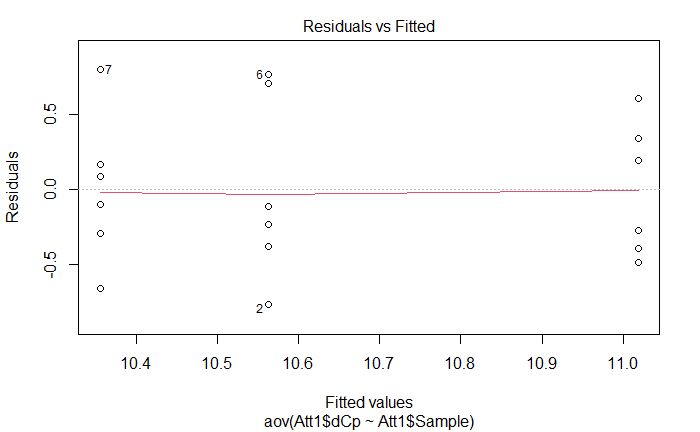

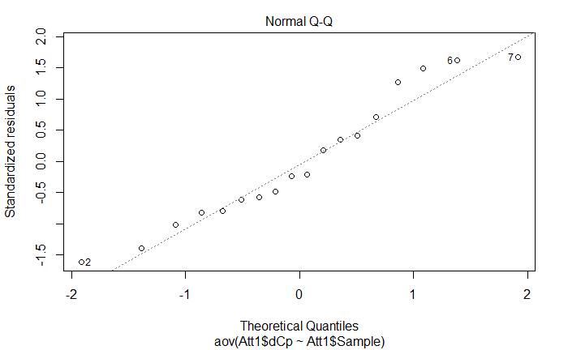

```
hat values (leverages) are all = 0.1666667
 and there are no factor predictors; no plot no. 5
```

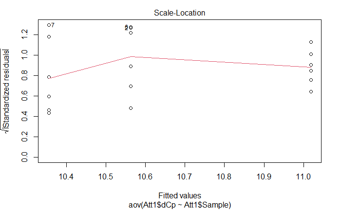

```r
a1 <- aov(Att1$dCp ~ Att1$Sample)
#checking the assumptions for anova
plot(a1)
```

Levene test to check the variance

```r
leveneTest(dCp ~ Sample, data = Att1)
```

```
group coerced to factor.
```

```
Levene's Test for Homogeneity of Variance (center = median)
      Df F value Pr(>F)
group  2  0.1877 0.8308
      15
```

The assumptions are met so we can perform anova

```r
anova(a1)
```

```
Analysis of Variance Table

Response: Att1$dCp
            Df Sum Sq Mean Sq F value Pr(>F)
Att1$Sample  2 1.3826 0.69132  2.5299  0.113
Residuals   15 4.0989 0.27326
```

Plotting the graph

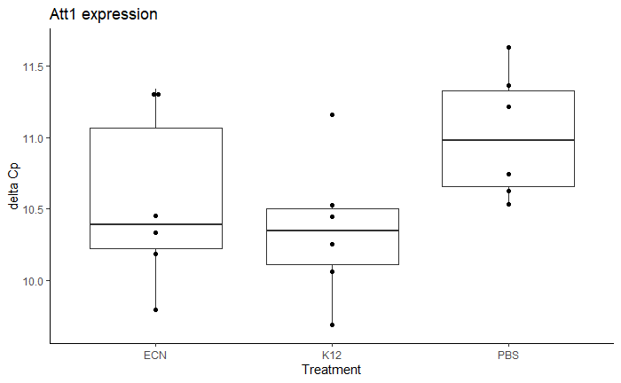

```r
p<-ggplot(Att1, aes(x=Sample, y=dCp,)) +
  geom_boxplot()
p1<-p + geom_dotplot(binaxis='y', stackdir='center', dotsize=0.5)+ scale_color_grey() + theme_classic()+labs(title="Att1 expression",x="Treatment", y = "delta Cp")
p1
```

#Att2

```r
shapiro.test(Att2$dCp) ##normal distribution
```

```
    Shapiro-Wilk normality test

data:  Att2$dCp
W = 0.92162, p-value = 0.1381
```

```r
a1 <- aov(Att2$dCp~Att2$Sample)
##Checking the assumptions

leveneTest(dCp ~ Sample, data = Att2)
```

```
group coerced to factor.
```

```
Levene's Test for Homogeneity of Variance (center = median)
      Df F value Pr(>F)
group  2   0.616 0.5532
      15
```

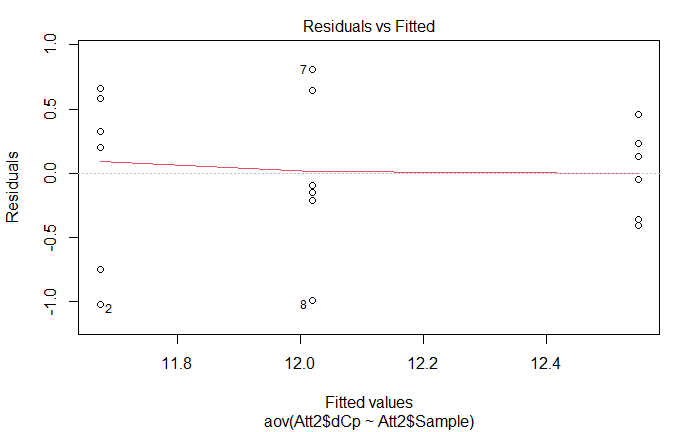

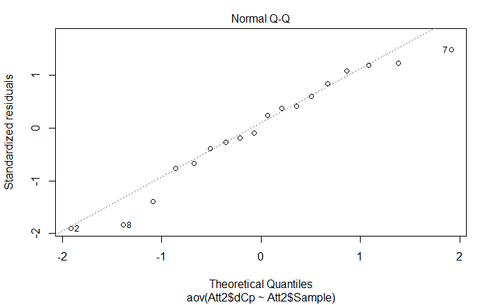

```
hat values (leverages) are all = 0.1666667
 and there are no factor predictors; no plot no. 5
```

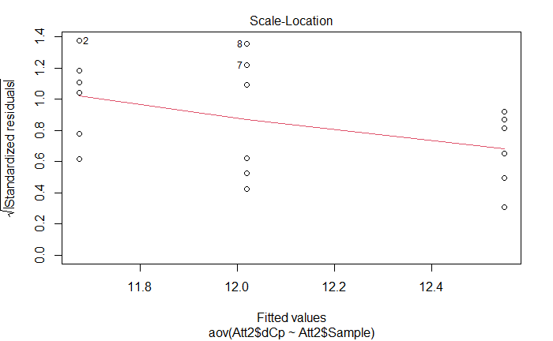

```r
plot(a1)
```

```r
anova(a1)
```

```
Analysis of Variance Table

Response: Att2$dCp
            Df Sum Sq Mean Sq F value  Pr(>F)
Att2$Sample  2 2.3350 1.16751  3.3417 0.06306 .
Residuals   15 5.2407 0.34938
---
Signif. codes:  0 ‘***’ 0.001 ‘**’ 0.01 ‘*’ 0.05 ‘.’ 0.1 ‘ ’ 1
```

```r
Tu<-TukeyHSD(a1)
Tu
```

```
  Tukey multiple comparisons of means
    95% family-wise confidence level

Fit: aov(formula = Att2$dCp ~ Att2$Sample)

$`Att2$Sample`
             diff         lwr      upr     p adj
K12-ECN 0.3454883 -0.54093099 1.231908 0.5806478
PBS-ECN 0.8757619 -0.01065734 1.762181 0.0530331
PBS-K12 0.5302736 -0.35614560 1.416693 0.2952283
```

```r
####shows a trend
```

Plotting the graph

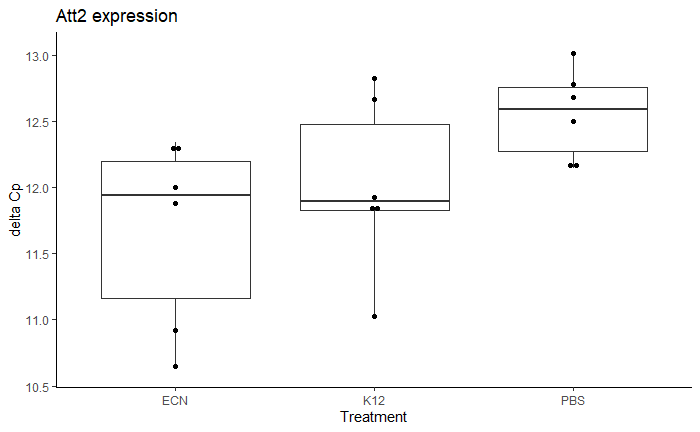

```r
p<-ggplot(Att2, aes(x=Sample, y=dCp,)) +
  geom_boxplot()
p2<-p + geom_dotplot(binaxis='y', stackdir='center', dotsize=0.5)+ scale_color_grey() + theme_classic()+labs(title="Att2 expression",x="Treatment", y = "delta Cp")
p2
```

## Defensin 2

```r
shapiro.test(Def2$dCp)
```

```
    Shapiro-Wilk normality test

data:  Def2$dCp
W = 0.97418, p-value = 0.8715
```

```r
a1 <- aov(Def2$dCp~Def2$Sample)
leveneTest(dCp ~ Sample, data = Def2)
```

```
group coerced to factor.
```

```
Levene's Test for Homogeneity of Variance (center = median)
      Df F value Pr(>F)
group  2  0.4144 0.6681
      15
```

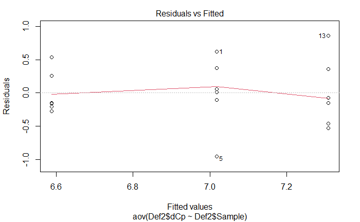

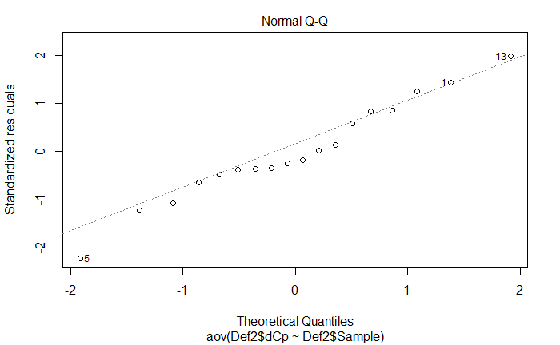

```
hat values (leverages) are all = 0.1666667
 and there are no factor predictors; no plot no. 5
```

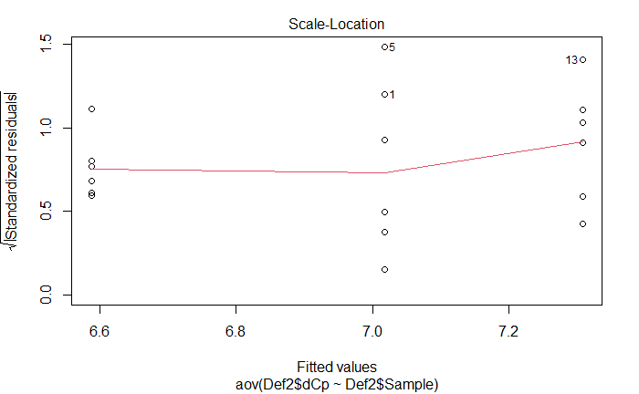

```r
plot(a1)
```

```r
anova(a1)  ##trend
```

```
Analysis of Variance Table

Response: Def2$dCp
            Df Sum Sq Mean Sq F value  Pr(>F)
Def2$Sample  2 1.5775 0.78876  3.5195 0.05582 .
Residuals   15 3.3617 0.22411
---
Signif. codes:  0 ‘***’ 0.001 ‘**’ 0.01 ‘*’ 0.05 ‘.’ 0.1 ‘ ’ 1
```

Plotting the data

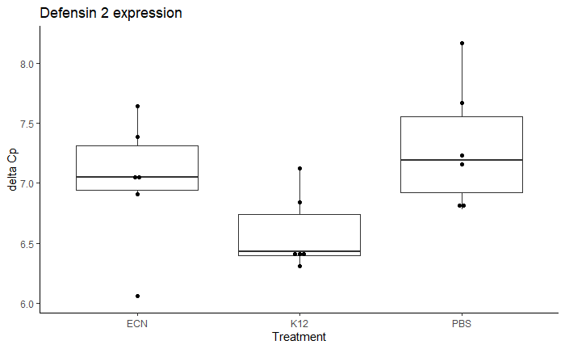

```r
p<-ggplot(Def2, aes(x=Sample, y=dCp,)) +
  geom_boxplot()

p3<-p + geom_dotplot(binaxis='y', stackdir='center', dotsize=0.5)+ scale_color_grey() + theme_classic()+labs(title="Defensin 2 expression",x="Treatment", y = "delta Cp")
p3
```